# Part II - U.S. Construction Spending: How Private Developers Allocate Capital

## by Jake Paredes

## Investigation Overview

This presentation conveys four key insights drawn from the exploratory analysis of 14 years of U.S. construction spending data (2002â€“2016):

1. Total private construction spending fell nearly 45% from peak to trough during the 2008 recession, with recovery still incomplete by 2016
2. Residential crashed immediately while office spending peaked during the recession â€” sectors follow fundamentally different cycles
3. Manufacturing overtook Commercial as the largest investment sector by 2013â€“2016, representing a complete reversal of pre-recession hierarchy
4. Public spending acted as a countercyclical stabilizer, rising as private investment retreated during the recession

## Dataset Overview

The dataset contains monthly U.S. construction spending figures from January 2002 to December 2016 (169 observations), sourced from the U.S. Census Bureau. Spending is broken down across 17 private and 17 public construction sectors, reported as annualized rates in millions of dollars. All values in this presentation have been converted to billions for readability.

## Slide 1 - The Boom, The Crash, and The Recovery

Private construction spending tells a dramatic story of boom, collapse, and slow recovery across 14 years. Total private investment peaked at 909B in 2006, then fell nearly 45% to a trough of 500.8B in 2011 â€” two full years after the official recession ended, confirming that construction recovery lags the broader economy. By 2016, spending had climbed back to 830B but had not yet reached its pre-recession peak.

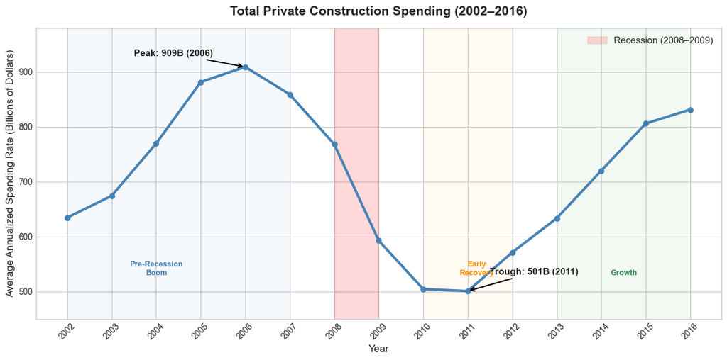

## Slide 2 - Not All Sectors Fall Equally

When the recession hit, residential construction collapsed immediately â€” falling 60% from its 630B peak to 250B by 2009. Office spending told a completely different story, actually peaking during the recession as developers completed already-committed projects. This lagged response reveals a critical insight: office investment is a lagging indicator, giving developers a 2-3 year warning window if they track residential as an early signal.

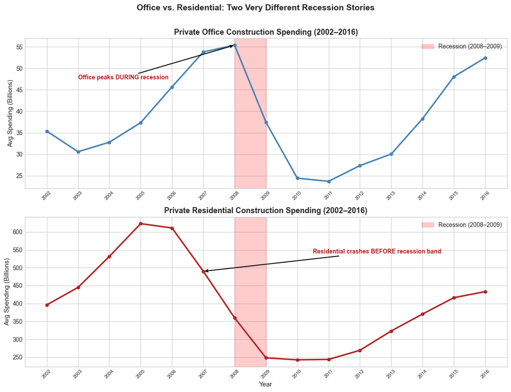

## Slide 3 - The Sector Hierarchy Reversal

Before the recession, Commercial real estate dominated private construction investment. By the Growth era (2013–2016), Manufacturing had overtaken Commercial as the largest sector — a complete reversal of the pre-recession hierarchy. This shift signals that post-recession private capital flowed into industrial infrastructure rather than traditional commercial real estate, fundamentally changing the landscape for developers.

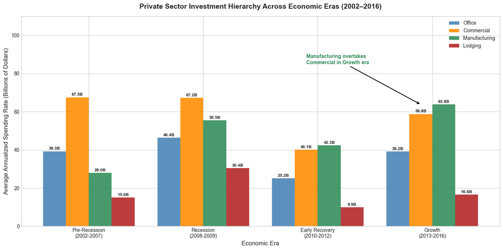

## Slide 4 - The Public Backstop

When private developers retreated during the recession, government construction investment did the opposite — rising from 237.9B to 311.1B while private spending fell sharply. This countercyclical relationship narrowed the private-to-public spending ratio from 3.3:1 pre-recession to just 1.8:1 during the Early Recovery era. For developers, understanding this dynamic is critical — public infrastructure investment partially sustained the construction workforce and supply chain during the years when private capital was scarce.

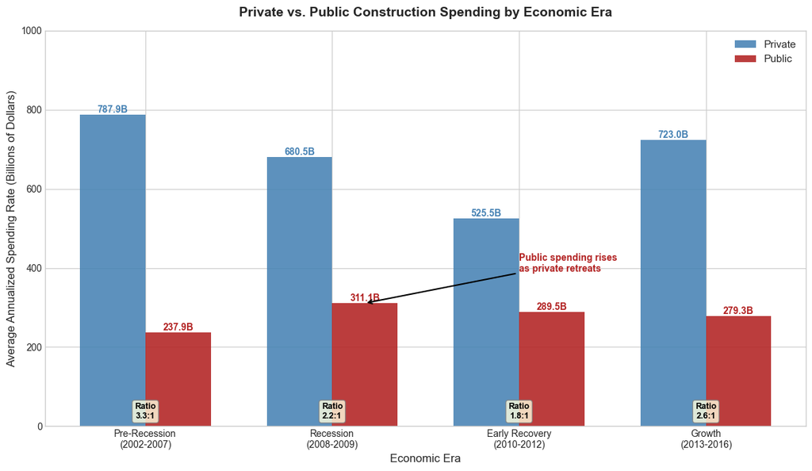